# HW 2B

2025-04-08

Use the Louvain and Leiden algorithm , and present a plot of both results. Which one should be chosen?

```r
library(igraph)
library(readxl)

rm(list = ls()) # clear memory

GitLink='https://raw.githubusercontent.com/Comp-Soc-Science-Methods/HW2/refs/heads/main/MyGraphs/case1.graphml'

# Get network
peru=read_graph(GitLink,format='graphml')
summary(peru)
```

```
## IGRAPH bf805f0 U-W- 37 135 --
## + attr: Multinacional (v/n), id (v/c), weight (e/n)
```

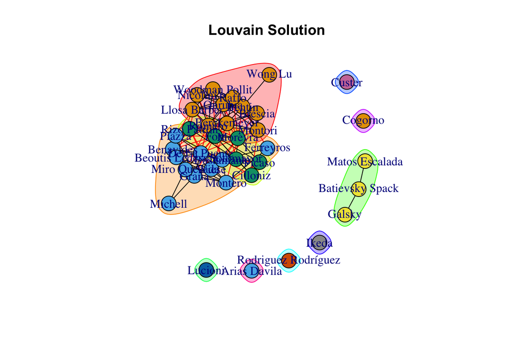

```r
V(peru)$name=V(peru)$id

# Plotting Louvain results
set.seed(111)

peru_lv <- cluster_louvain(peru)
plot(peru_lv, peru,
     layout = layout_with_kk,
     main ="Louvain Solution")
```

```r
modularity(peru, membership(peru_lv), directed=FALSE)
```

```
## [1] 0.2876269
```

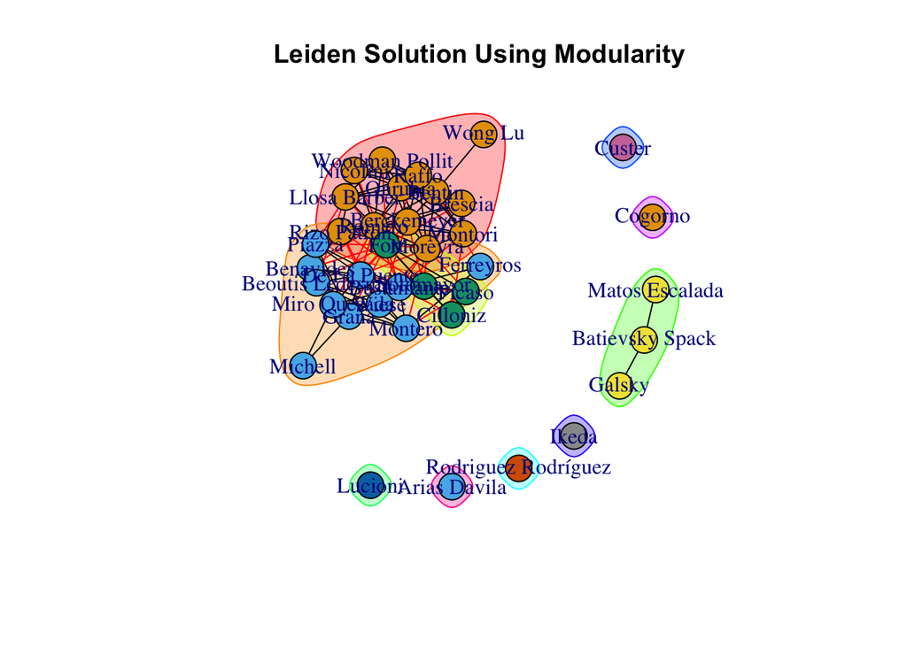

```r
# Plotting Leiden results
peru_ld <- cluster_leiden(peru)
set.seed(123)
peru_ld_mod <- cluster_leiden(peru,
                              objective_function = "modularity")

plot(peru_ld_mod, peru,
     layout = layout_with_kk,
     main="Leiden Solution Using Modularity")
```

```r
modularity(peru, membership(peru_ld_mod))
```

```
## [1] 0.2886145
```

Use the Seattle graph, and prepare a code in R to answer: Use the Louvain and Leiden algorithm. Did any of them work? If it did not work, choose two other algorithms, and plot the result. Which one should be chosen from the two algorithms you chose?

The Louvain and Leiden algorithms do not work with directed graphs, so I’ve chosen to use Girvan-Newmann and infomap. Girvan-Newmann is the more useful algorithm in this case, as it produces a higher modularity value and indicates more community connectedness visually (ex. green area).

```r
GitLink_2='https://raw.githubusercontent.com/Comp-Soc-Science-Methods/HW2/refs/heads/main/MyGraphs/case2.graphml'

# Get network
sea=read_graph(GitLink_2,format='graphml')
V(sea)$name=V(sea)$id
sea_giant=CINNA::giant_component_extract(sea)[[1]]
summary(sea_giant)
```

```
## IGRAPH 1213cdd DNW- 46 588 --
## + attr: male (v/n), id (v/c), name (v/c), weight (e/n)
```

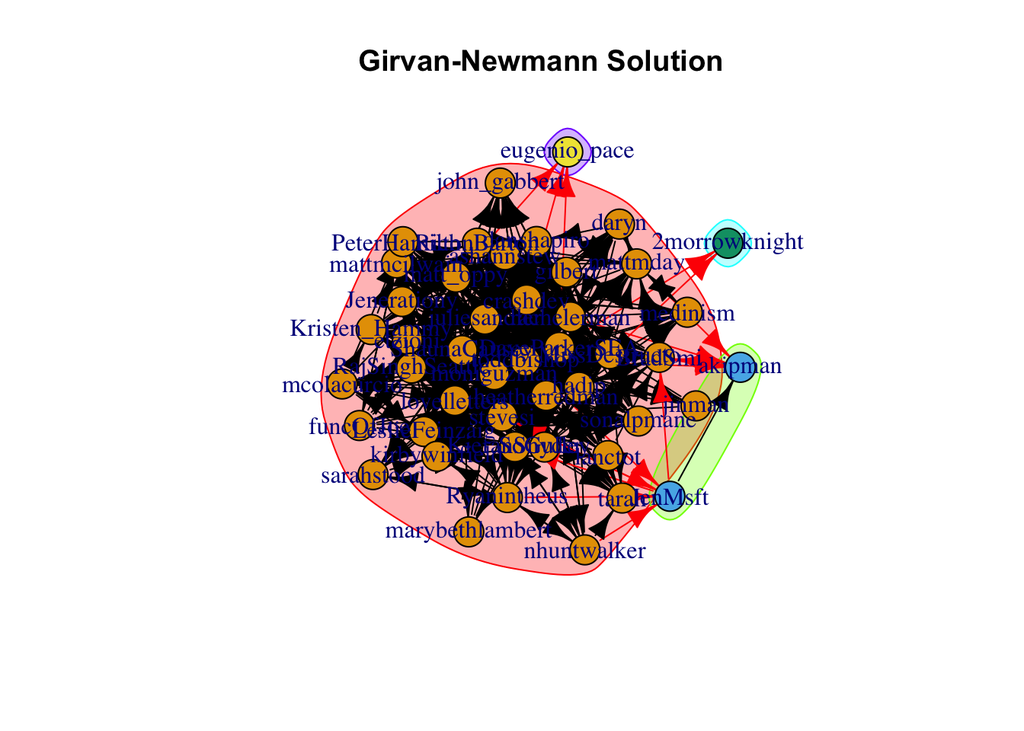

```r
# Plotting Girvan-Newmann
set.seed(333)
sea_gn <- cluster_edge_betweenness(sea_giant,directed = T)
plot(sea_gn, sea,
     layout = layout_with_kk,
     main="Girvan-Newmann Solution")
```

```r
modularity(sea_giant, membership(sea_gn))
```

```
## [1] 0.003039821
```

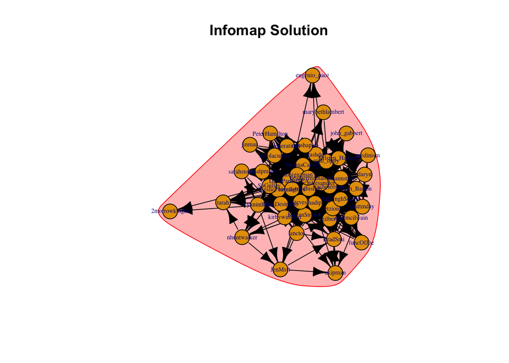

```r
# Plotting infomap
sea_im <- cluster_infomap(sea_giant)
plot(sea_im, sea,
     layout = layout_nicely, vertex.label.cex=0.5,
     main="Infomap Solution")
```

```r
modularity(sea_giant, membership(sea_im))
```

```
## [1] 0
```

Use the Fifa graph, projecting only the countries (network of countries), and report: Use the Girvan-Newman and Leiden algorithm, and present a plot of both results. Which one should be chosen?

The Leiden algorithm should definitely be chosen in this case. Again, visually and through the modularity value (higher than Girvan-Newmann), you can get a better read for community connectedness.

```r
GitLink_3='https://raw.githubusercontent.com/Comp-Soc-Science-Methods/HW2/refs/heads/main/MyGraphs/country_projection.graphml'

# Get network
fifa=read_graph(GitLink_3,format='graphml')
V(fifa)$name=V(fifa)$id
summary(fifa)
```

```
## IGRAPH 9deed7b UNW- 32 305 --
## + attr: bipartite (v/n), id (v/c), name (v/c), weight (e/n)
```

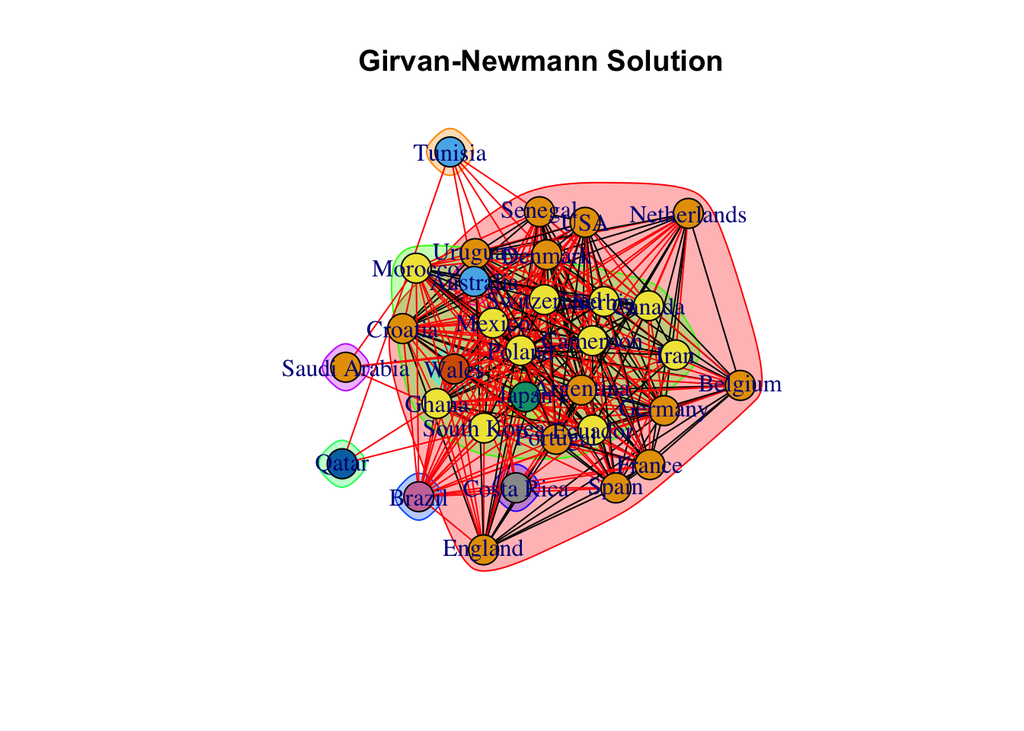

```r
# Plotting Girvan-Newmann
set.seed(123)
fifa_gn <- cluster_edge_betweenness(fifa,directed = F)
plot(fifa_gn, fifa,
     layout = layout_with_kk,
     main = "Girvan-Newmann Solution")
```

```r
modularity(fifa, membership(fifa_gn))
```

```
## [1] 0.01644719
```

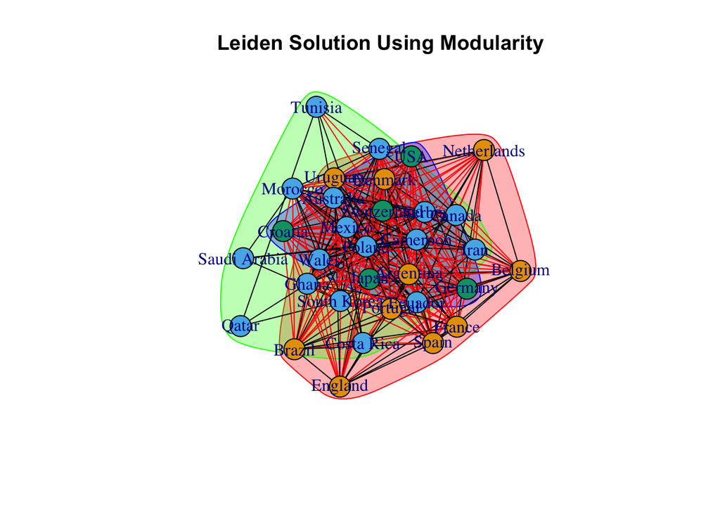

```r
# Plotting Leiden
fifa_ld <- cluster_leiden(fifa)
set.seed(123)
fifa_ld_mod <- cluster_leiden(fifa,
                              objective_function = "modularity")

plot(fifa_ld_mod, fifa,
     layout = layout_with_kk,
     main="Leiden Solution Using Modularity")
```

```r
modularity(fifa, membership(fifa_ld_mod))
```

```
## [1] 0.03432948
```